# Discriminant Analysis

João Neto

October 2014

## Introduction

Refs

- [DM825 - Intro.to ML, Lecture 7](http://www.imada.sdu.dk/~marco/DM825/Slides/dm825-lec7.pdf)
- **C.M.Bishop - Pattern Matching and ML**, pgs 201,203

The Gaussian Discriminant Analysis (GDA) is a generative method, given data $x$ and class $y$, we learn $p(x,y)$ and thus predict $p(y|x)$.

The general steps for a generative model are:

1. Model $p(y)$ and $p(x|y)$
2. Learn parameters of the model by maximizing $p(x,y)=p(x|y)p(y)$
3. With $p(y|x) = \frac{p(x|y)p(y)}{p(x)} = \frac{p(x|y)p(y)}{\sum_{y_i\in Y}p(x|y_i)p(y_i)} \propto p(x|y)p(y)$ predict $p(y|x)$ by $\arg \max_y p(y|x) = \arg \max_y \frac{p(x|y)p(y)}{p(x)} = \arg \max_y p(x|y)p(y)$

Let’s consider two classes for $y$, $y_0 = 0, y_1 = 1$.

**Step 1.** In GDA we model $p(y)$ as:

$y \sim \text{Bernoulli}(\phi) \implies p(y|\phi) = \phi^y(1-\phi)^{1-\phi}$

and model $p(x|y)$ by a multivariate Gaussian with a given covariance matrix $\Sigma$:

$x|y_i \sim \mathcal{N}(\mu_i,\Sigma) \implies p(x|y_i) = \frac{1}{(2\pi)^{n/2}|\Sigma|^{1/2}} \exp( \frac{1}{2} (x-\mu_i)^T \Sigma^{-1} (x-\mu_i) )$

**Step 2.** Express the joint likelihood of the data $x=(x^1,x^2,\ldots,x^m), y=(y^1,y^2,\ldots,y^m)$:

$p(x,y|\phi,\mu_0,\mu_1,\Sigma) = \prod_{i=1}^m p(x^i,y^i) = \prod_{i=1}^m p(x^i|y^i)p(y^i)$

and maximize the expression in $\phi,\mu_0,\mu_1,\Sigma$.

The solutions are:

$\phi = \frac{\sum_i I(y^i = 1)}{m}$

$\mu_k = \frac{\sum_i I(y^i = k)x^i}{I(y^i = k)}$

$\Sigma = \frac{1}{m} \sum_{I(y^i=0)} (x^i-\mu_0)(x^i-\mu_0)^T + \frac{1}{m} \sum_{I(y^i=1)} (x^i-\mu_1)(x^i-\mu_1)^T$

**Step 3.** Given the parameters, maximize $\arg \max_y p(x|y)p(y)$ With two classes it is finding which $p(x|y=0)p(y=0)$ or $p(x|y=1)p(y=1)$ is larger.

Herein, we assumed that $\Sigma$ is the same for both class conditional densities. This is called **Linear Discriminant Analysis**. Otherwise, it is called **Quadratic Discriminant Analysis**.

## Linear Discriminant Analysis

Refs:

- http://web.bahcesehir.edu.tr/atabey_kaygun/other/lda.html

Linear Discriminant Analysis (LDA) finds a linear combination of features that separates different classes. This combination can be used to perform classification or for dimensionality reduction before classification (using another method).

> LDA is closely related to […] regression analysis, which also attempt to express one dependent variable as a linear combination of other features or measurements. In [regression analysis] however, the dependent variable is a numerical quantity, while for LDA it is a categorical variable (i.e. the class label). Logistic regression and probit regression are more similar to LDA, as they also explain a categorical variable. These other methods are preferable in applications where it is not reasonable to assume that the independent variables are normally distributed, which is a fundamental assumption of the LDA method. [wikipedia](http://en.wikipedia.org/wiki/Linear_discriminant_analysis)

Consider a classification problem with $K$ classes. Each class $C_i$ has $N_i$ m-dimensional samples. Let $X$ be a matrix where each column corresponds to one sample. The goal is to obtain a transformation of $X$ to $X'$ by projecting the samples of $X$ onto a hyperplane of dimension $K-1$.

In two dimensions (2 classes) we want to project the matrix onto a line the maximizes the separability of the classes (images from Aly Farag’s [LDA Tutorial](https://cvl.gist.ac.kr/wp-content/uploads/2013/11/LDA-Tutorial.pdf)):

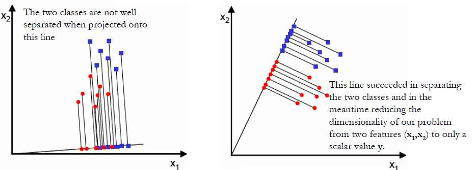

LDA is a parametric method, ie, they assume some distribution over the data, in this case unimodal Gaussian likelihoods. If the distribution is significantly non-gaussian, LDA will perform badly since it will be unable to preserve the complex strucutre of the data. However, by assuming a distribution, it’s possible to assign probabilities for group assignments (as shown in the next section).

If the discriminatory information is not in the mean, but in the variance, LDA will fail:

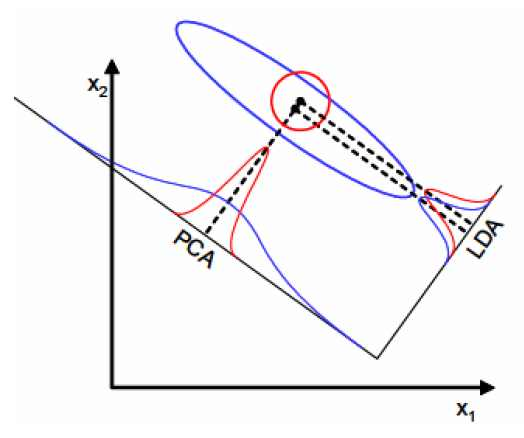

## The Basic Idea

Let a sample $x^T = (x_1, \ldots, x_m)$ where $x_i$ is a random variable.

We assume that $x$ follows a Multivariate Normal Distribution (MVD) with mean $\mu$ (a m-dimensional vector) and covariance matrix $\Sigma$ (a mm matrix), ie, $x \sim N(\mu,\Sigma)$.

The pdf is:

$f(x|\mu,\Sigma) = \frac{1}{(2\pi)^{m/2} |\Sigma|^{1/2}} exp \Big[ -\frac{1}{2} (x-\mu)^T \Sigma^{-1} (x-\mu) \Big]$

Notice that the set $\{x:f(x|\mu,\Sigma)>C\}$ is a m-dimensional ellipsoid centered at point $\mu$, where $\Sigma$ determines the ellipsoid’s shape.

Eg, for $\mu=(0,0)$ and $\Sigma = (1,0.8;0.8,3)$ the contour plot is:

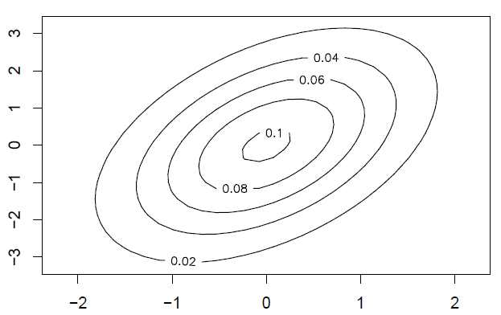

Def: The [Mahalanobis distance](http://en.wikipedia.org/wiki/Mahalanobis_distance) of a point $x$ to mean $\mu$ is

$D = \sqrt{ (x-\mu)^T \Sigma^{-1} (x-\mu) }$

Two points have the same Mahalanobis distance if they are on the same ellipsoid centered on $\mu$.

Now suppose that given a point $x$ we wish the find the closest mean $\mu_k$ (of class $K$) measured by the Mahalanobis distance. A point is closer to $\mu_1$ than it is to $\mu_2$ when

$(x-\mu_1)^T \Sigma^{-1}_1 (x-\mu_1) < (x-\mu_2)^T \Sigma^{-1}_2 (x-\mu_2)$

this is a quadratic expression on $x$.

If we assume that all covariance matrixes are equal, $\Sigma = \Sigma_k, k=1\ldots K$, the expression simplifies to $-2\mu_1^T\Sigma^{-1}x + \mu_1^T\Sigma^{-1}\mu_1 < -2\mu_2^T\Sigma^{-1}x + \mu_2^T\Sigma^{-1}\mu_2$ which is a linear expression of $x$.

There are linear and quadratic discriminant analysis (QDA), depending on the assumptions we make. In LDA the different covariance matrixes are grouped into a single one, in order to have that linear expression. This makes it simpler but all the class groups share the same structure. In QDA the ellipsoid’s shapes vary.

To classify a new sample, we must compute the posterior $p(x \in C_k|x)$. The classification is just to assign the class with largest posterior probability. The likelihood of the data $p(x)$ is the MVD as seen above. The only thing needed to apply Bayes’ theorem is a prior probability of $P(x \in C_k)$ which usually is just the proportion of samples belonging to class $C_k$. Another option is to have a vague prior $P(x \in C_k) = 1/K$

In LDA the decision boundary between classes $i$ and $j$ is given by $\log \frac{p(x \in i|x)}{p(x \in j|x)} = 0$

## LDA for Classification

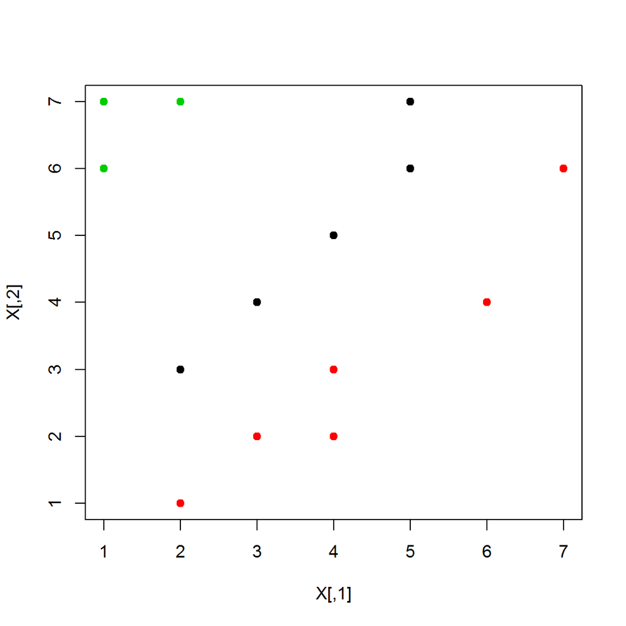

```r
library(MASS)

X <- matrix(c(2,3,3,4,4,5,5,6,5,7,2,1,3,2,4,2,4,3,6,4,7,6,1,6,2,7,1,7), ncol=2, byrow=T)
Y <- c(1,1,1,1,1,2,2,2,2,2,2,3,3,3);
plot(X,col=Y, pch=19)
```

```r
idx_class1 <- which(Y==1)  # indexes of the observations for each class
idx_class2 <- which(Y==2)

my.data <- data.frame(X1=X[,1], X2=X[,2], Y=Y)
model <- lda(Y ~ . , data=my.data)
model
```

```
## Call:
## lda(Y ~ ., data = my.data)
##
## Prior probabilities of groups:
##      1      2      3
## 0.3571 0.4286 0.2143
##
## Group means:
##      X1    X2
## 1 3.800 5.000
## 2 4.333 3.000
## 3 1.333 6.667
##
## Coefficients of linear discriminants:
##       LD1    LD2
## X1 -2.025 0.3695
## X2  1.963 0.2946
##
## Proportion of trace:
##    LD1    LD2
## 0.9985 0.0015
```

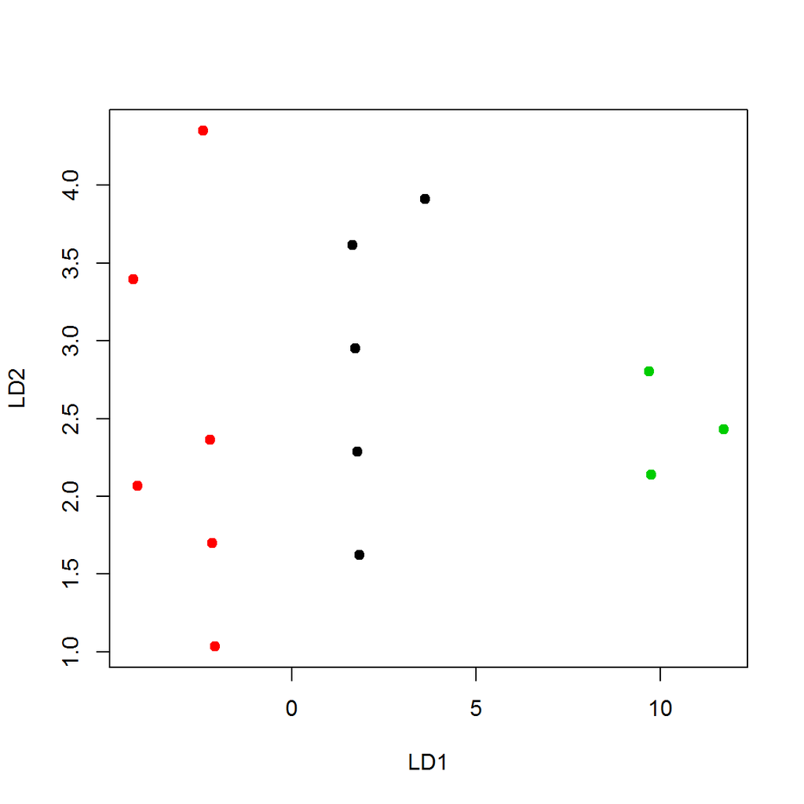

```r
projected.data <- X %*% model$scaling
plot(projected.data, col=Y, pch=19)
```

```r
# now let's predict the class of a new sample
new.data <- data.frame(X1=c(2), X2=c(5.1)) # new data point should be class 3
prediction <- predict(model, new.data)
model$prior          # the prior probabilities before the new data point
```

```
##      1      2      3
## 0.3571 0.4286 0.2143
```

```r
prediction$posterior # the posterior probs for the classes given this new data point
```

```
##        1         2       3
## 1 0.9397 2.148e-14 0.06026
```

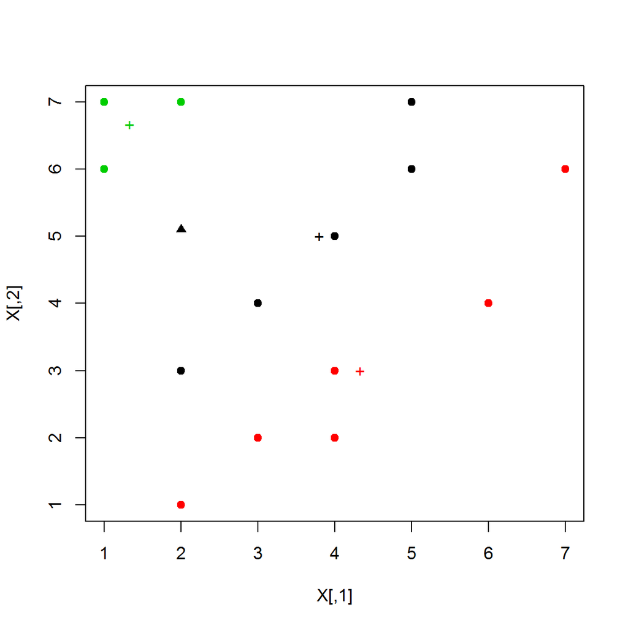

```r
plot(X,col=Y, pch=19)
# Let's plot it with the color for the class it predicts:
points(new.data$X1, new.data$X2, pch=17, col=prediction$class)
# Plot the means:
points(model$means, pch="+", col=1:3)
```

Let’s see the boundaries:

```r
library(klaR) # Classification and visualization package
```

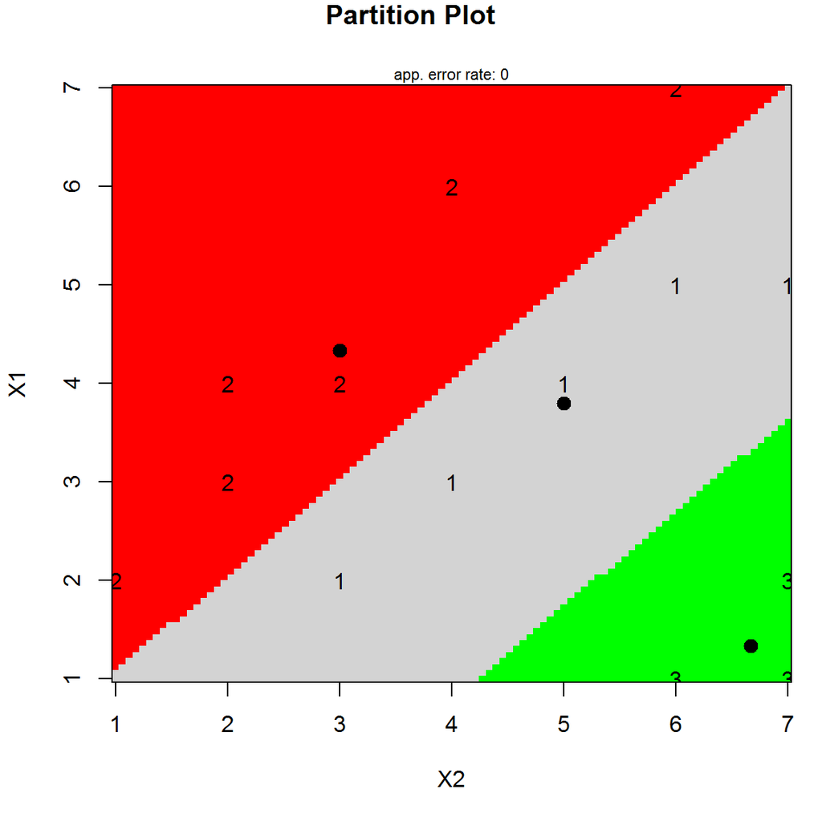

```r
partimat(x=my.data[,-3], grouping=as.factor(my.data[,3]), method="lda",
         col.mean=1, image.colors = c("lightgrey","red","green"))
```

Let’s do the same for QDA:

```r
model <- qda(Y ~ . , data=my.data)

new.data <- data.frame(X1=c(2), X2=c(5.1)) # new data point should be class 3
prediction <- predict(model, new.data)
prediction$posterior
```

```
##           1         2      3
## 1 5.404e-05 8.262e-14 0.9999
```

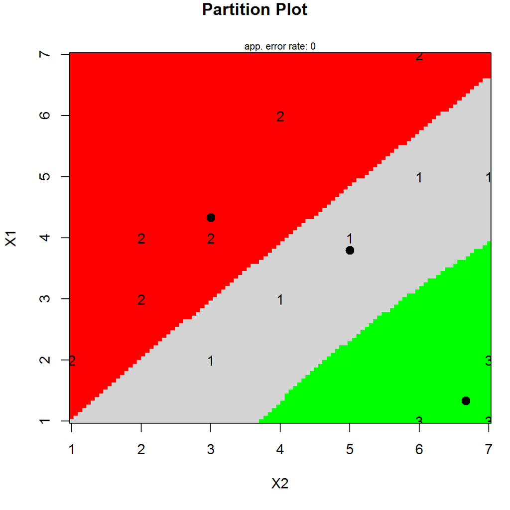

```r
partimat(x=my.data[,-3], grouping=as.factor(my.data[,3]), method="qda",
         col.mean=1, image.colors = c("lightgrey","red","green"))
```

## LDA for Dimensionality Reduction before Classification

Here the objective is to perform dimensionality reduction. But unlike PCA it preserves as much class information as possible.

Let’s see an eg:

```r
set.seed(101)
# Read Sample Data
my.data <- read.csv(url("http://archive.ics.uci.edu/ml/machine-learning-databases/wine/wine.data"),
                    header=FALSE)
Y <- my.data[,1]                            # classes
X <- as.data.frame(scale(my.data[,2:14]))   # scaling data (ie, mean=0 & sd=1 for all Xi)
names(X) <- paste0("X",1:13)
head(cbind(signif(X,3),Y), n=10)
```

```
##       X1      X2     X3     X4      X5    X6    X7     X8     X9      X10
## 1  1.510 -0.5610  0.231 -1.170  1.9100 0.807 1.030 -0.658  1.220  0.25100
## 2  0.246 -0.4980 -0.826 -2.480  0.0181 0.567 0.732 -0.818 -0.543 -0.29200
## 3  0.196  0.0212  1.110 -0.268  0.0881 0.807 1.210 -0.497  2.130  0.26800
## 4  1.690 -0.3460  0.487 -0.807  0.9280 2.480 1.460 -0.979  1.030  1.18000
## 5  0.295  0.2270  1.840  0.451  1.2800 0.807 0.661  0.226  0.400 -0.31800
## 6  1.480 -0.5160  0.304 -1.290  0.8580 1.560 1.360 -0.176  0.662  0.73000
## 7  1.710 -0.4170  0.304 -1.470 -0.2620 0.327 0.491 -0.497  0.680  0.08280
## 8  1.300 -0.1670  0.888 -0.567  1.4900 0.487 0.481 -0.417 -0.596 -0.00349
## 9  2.250 -0.6230 -0.716 -1.650 -0.1920 0.807 0.952 -0.577  0.680  0.06120
## 10 1.060 -0.8830 -0.352 -1.050 -0.1220 1.090 1.120 -1.140  0.453  0.93300
##       X11   X12     X13 Y
## 1   0.361 1.840  1.0100 1
## 2   0.405 1.110  0.9630 1
## 3   0.317 0.786  1.3900 1
## 4  -0.426 1.180  2.3300 1
## 5   0.361 0.448 -0.0378 1
## 6   0.405 0.336  2.2300 1
## 7   0.274 1.360  1.7200 1
## 8   0.449 1.360  1.7400 1
## 9   0.536 0.336  0.9470 1
## 10  0.230 1.320  0.9470 1
```

```r
train <- sample(1:dim(X)[1],50)  # define the training set indexes

# First test with a knn
library(class)
prediction <- knn(X[train,], X[-train,], Y[train], k=1)
table1 <- table(old=Y[-train], new=prediction)
table1
```

```
##    new
## old  1  2  3
##   1 40  0  0
##   2  6 42  2
##   3  0  1 37
```

This is the result of applying KNN.

The next test reduces the dataset by performing a LDA. Then we classify:

```r
library(MASS)
model <- lda(Y ~ . , data=cbind(X,Y), subset=train)
model$prior   # the prior probabilities used (by default, the class proportions for the training set)
```

```
##    1    2    3
## 0.38 0.42 0.20
```

```r
model$scaling # the resulting projection matrix to project our dataset into a 2-dimensional vector space
```

```
##          LD1      LD2
## X1   0.10022  0.94483
## X2   0.09533  0.53392
## X3  -0.09877  0.44207
## X4   1.17750  0.01822
## X5  -0.27711  0.04414
## X6   0.48982  0.09809
## X7  -1.17528 -0.60382
## X8  -0.33679 -0.19981
## X9   0.07134 -0.02638
## X10  1.03978  0.90507
## X11  0.10599 -0.02142
## X12 -1.36311 -0.10682
## X13 -1.23186  0.65014
```

```r
projected.data <- as.matrix(X) %*% model$scaling  # make the projection to 2D space
head(projected.data)
```

```
##         LD1     LD2
## [1,] -5.793  1.5313
## [2,] -6.177 -0.4178
## [3,] -3.611  1.1317
## [4,] -4.511  3.6466
## [5,] -1.241  0.5314
## [6,] -4.821  2.6848
```

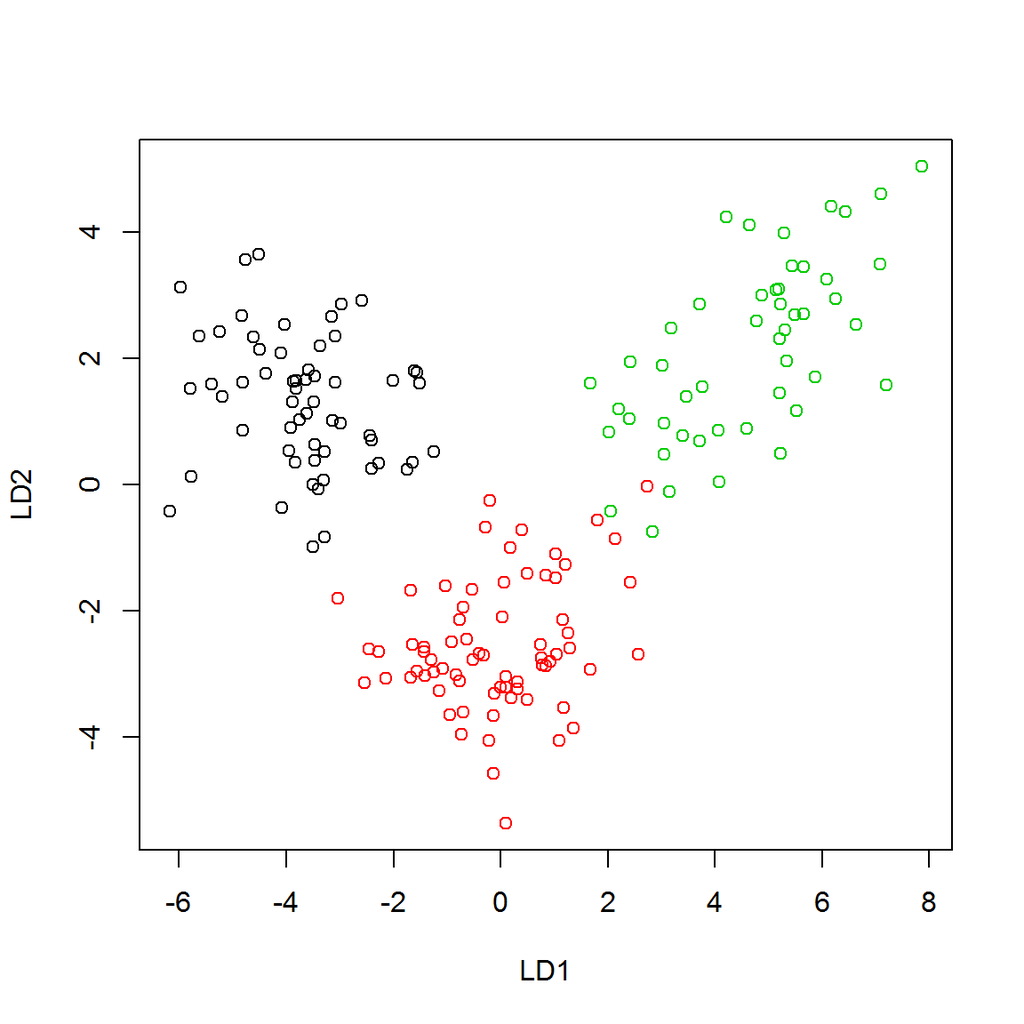

```r
plot(projected.data, col=Y)
```

```r
prediction <- knn(projected.data[train,], projected.data[-train,], Y[train], k=1) # Now let's reapply knn:
table2 <- table(old=Y[-train], new=prediction)
table2
```

```
##    new
## old  1  2  3
##   1 40  0  0
##   2  1 45  4
##   3  0  0 38
```

We have greatly improved the training error, from 9 misclassifications to just 5.

## LDA projections (iris eg)

```r
library(MASS)

X <- scale(as.matrix(iris[,-5])) # better scale mean and variance before LDA
Y <- unclass(iris$Species)
iris1 <- data.frame(X=X, Y=Y)
colnames(iris1) <- colnames(iris)
head(iris1)
```

```
##   Sepal.Length Sepal.Width Petal.Length Petal.Width Species
## 1      -0.8977     1.01560       -1.336      -1.311       1
## 2      -1.1392    -0.13154       -1.336      -1.311       1
## 3      -1.3807     0.32732       -1.392      -1.311       1
## 4      -1.5015     0.09789       -1.279      -1.311       1
## 5      -1.0184     1.24503       -1.336      -1.311       1
## 6      -0.5354     1.93331       -1.166      -1.049       1
```

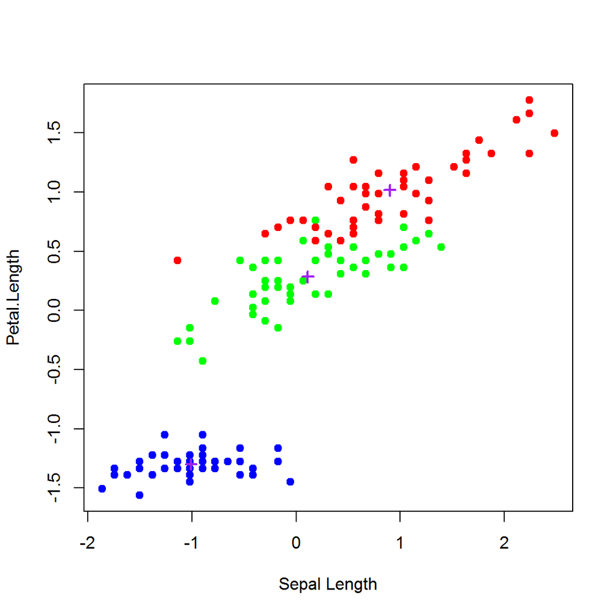

```r
model <- lda(Species ~ . , data=iris1, prior=c(1,1,1)/3)

plot(iris1[,"Sepal.Length"], iris1[,"Petal.Length"],
     col=c("blue","green","red")[iris1$Species], pch=19,
     xlab="Sepal Length", ylab="Petal.Length")

means <- model$means
points(means[,c(1,3)], pch=3, lwd=2, col="purple")
```

```r
model
```

```
## Call:
## lda(Species ~ ., data = iris1, prior = c(1, 1, 1)/3)
##
## Prior probabilities of groups:
##      1      2      3
## 0.3333 0.3333 0.3333
##
## Group means:
##   Sepal.Length Sepal.Width Petal.Length Petal.Width
## 1      -1.0112      0.8504      -1.3006     -1.2507
## 2       0.1119     -0.6592       0.2844      0.1662
## 3       0.8993     -0.1912       1.0163      1.0845
##
## Coefficients of linear discriminants:
##                  LD1      LD2
## Sepal.Length  0.6868  0.01996
## Sepal.Width   0.6688  0.94344
## Petal.Length -3.8858 -1.64512
## Petal.Width  -2.1422  2.16414
##
## Proportion of trace:
##    LD1    LD2
## 0.9912 0.0088
```

```r
model$scaling # the parameters of the linear discriminant functions
```

```
##                  LD1      LD2
## Sepal.Length  0.6868  0.01996
## Sepal.Width   0.6688  0.94344
## Petal.Length -3.8858 -1.64512
## Petal.Width  -2.1422  2.16414
```

Eg, the first discriminant function is a linear combination of the variables

$0.687 \times \text{Sepal Length} + 0.669\times \text{Sepal Width} - 3.886 \times \text{Petal Length} - 2.14 \times \text{Petal Width}$

We can use `predict` to calculate the value of a discriminant function for each sample in the data set

```r
pred <- predict(model, iris[,-5])

# The next horizontal axis are meaningless, they depends on the sample order of the dataset
head(pred$x[,1]) # contains the values of the dataset observations for the first discriminant function
```

```
##        1        2        3        4        5        6
## -0.02510 -0.49687 -0.11188 -1.02460 -0.02689 -1.14572
```

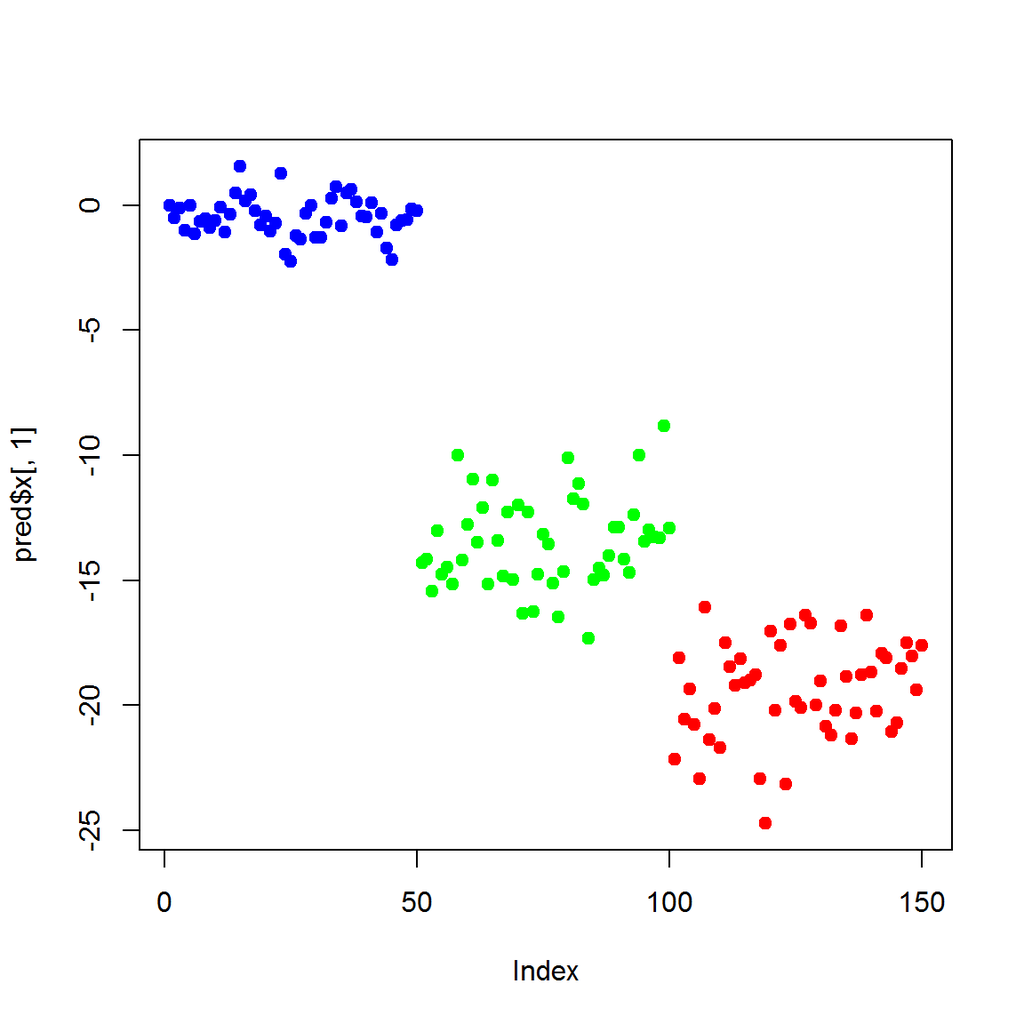

```r
plot(pred$x[,1], col=c("blue","green","red")[iris1$Species], pch=19) # we can plot them
```

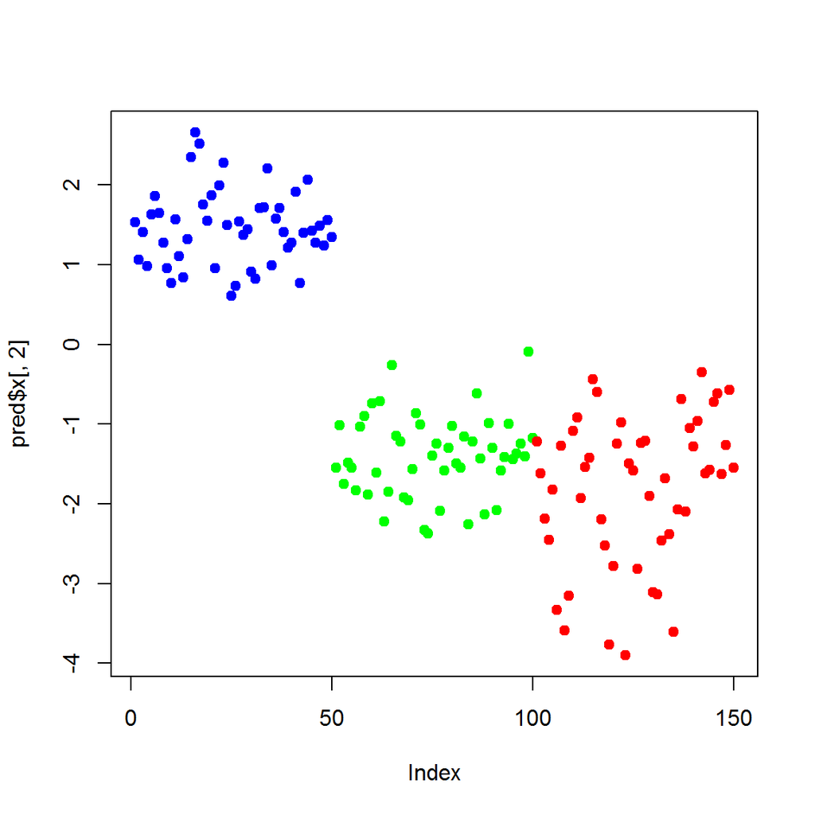

```r
# Notice that the 2nd discriminant function does not separate that well the 2nd & 3rd class
plot(pred$x[,2], col=c("blue","green","red")[iris1$Species], pch=19) # we can plot them
```

Let’s use Sepal.Length and Petal.Length to vizualize the projections by both linear discriminant functions

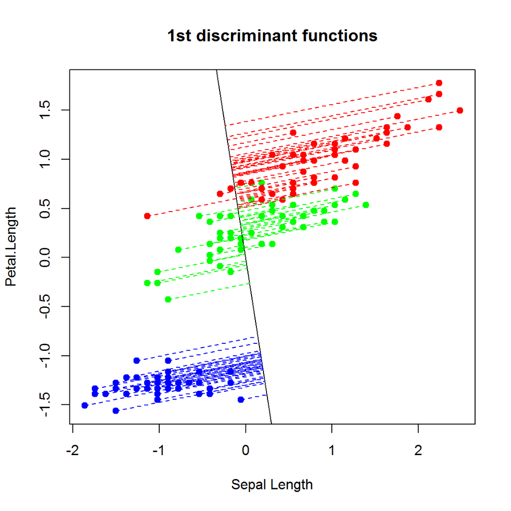

```r
vec <- c(model$scaling[1,1], model$scaling[3,1])
v   <- vec / sqrt(sum(vec^2))  # make it a unit vector
lda1.points <- as.matrix(iris1[,c(1,3)]) %*% v %*% t(v) # to project point X into unit vector v just calculate X.v.v^T

plot(iris1[,"Sepal.Length"], iris1[,"Petal.Length"],
     col=c("blue","green","red")[iris1$Species], pch=19,
     xlab="Sepal Length", ylab="Petal.Length", ,  main="1st discriminant functions")
segments(-vec[1],-vec[2],vec[1],vec[2])
# points(lda1.points , col=c("blue","green","red")[iris1$Species], pch=18) # draw projection point
for(i in 1:nrow(iris1)) {
  segments(iris1[i,1], iris1[i,3], lda1.points[i,1], lda1.points[i,2],
           lty=2, col=c("blue","green","red")[iris1[i,]$Species])
}
```

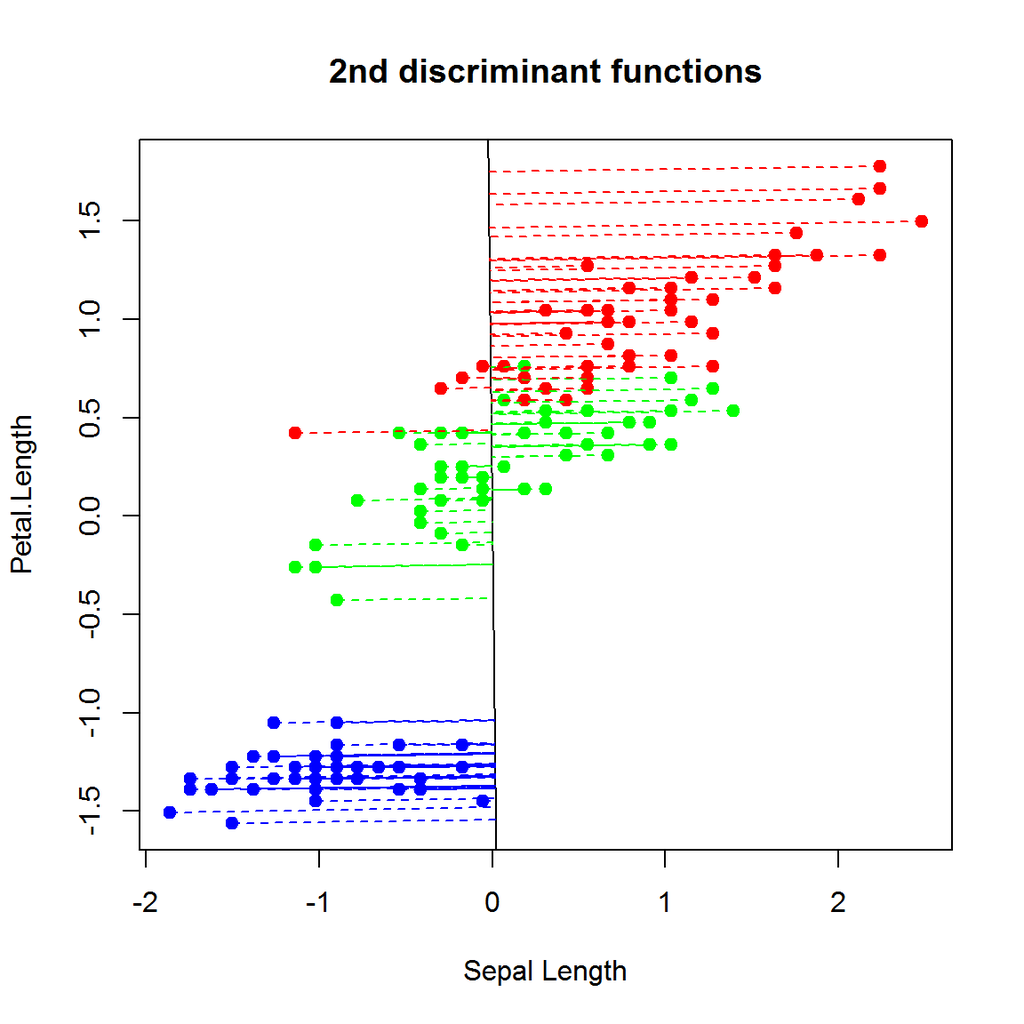

```r
vec <- c(model$scaling[1,2], model$scaling[3,2])
v   <- vec / sqrt(sum(vec^2))
lda2.points <- as.matrix(iris1[,c(1,3)]) %*% v %*% t(v)

plot(iris1[,"Sepal.Length"], iris1[,"Petal.Length"],
     col=c("blue","green","red")[iris1$Species], pch=19,
     xlab="Sepal Length", ylab="Petal.Length", ,  main="2nd discriminant functions")
segments(-2*vec[1],-2*vec[2],2*vec[1],2*vec[2])
# points(lda2.points , col=c("blue","green","red")[iris1$Species], pch=18) # draw projection point
for(i in 1:nrow(iris1)) {
  segments(iris1[i,1], iris1[i,3], lda2.points[i,1], lda2.points[i,2],
           lty=2, col=c("blue","green","red")[iris1[i,]$Species])
}
```